# “Reproducible Research: Peer Assessment 1”

## Question 3.0

### Imputing missing values

3.1 Calculate and report the total number of missing values in the dataset (i.e. the total number of rows with NAs) ### Rcode 3.1

```r
sum(is.na(Data)) #Ans: 2304 NAs in entire dataset
```

[1] 2304

```r
sum(is.na(Data$steps)) #col1 has all the NAs
```

[1] 2304

```r
sum(is.na(Data$date)) #col2 does not have missing values
```

[1] 0

```r
sum(is.na(Data$interval)) #col3 does not have missing values
```

[1] 0 ##Answer 3.1 There are 2304 NAs in the data set, all of them in the column with steps measurements

3.3 Create a new dataset that is equal to the original dataset but with the missing data filled in. ### Rcode 3.3

```r
library(Hmisc)
```

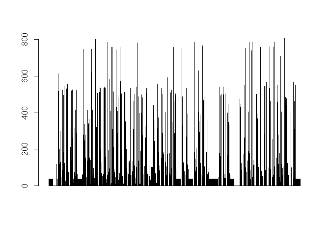

```r
cleandata_mean <- Data
cleandata_mean$steps <- impute(Data$steps, fun=mean)
barplot(as.numeric(cleandata_mean$steps))
```

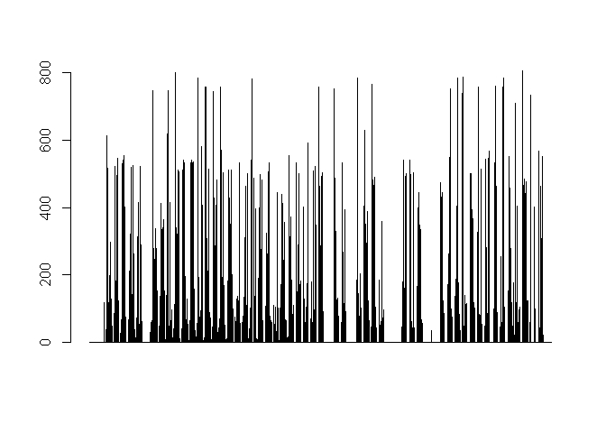

```r
cleandata_median <- Data
cleandata_median$steps <- impute(Data$steps, fun=median)
barplot(as.numeric(cleandata_median$steps))
```

3.4a Make a histogram of the total number of steps taken each day. ### Rcode 3.4a

```r
dailysteps_mean <- aggregate(steps ~ date, data = cleandata_mean, FUN = sum)
dailysteps_median <- aggregate(steps ~ date, data = cleandata_median, FUN = sum)
```

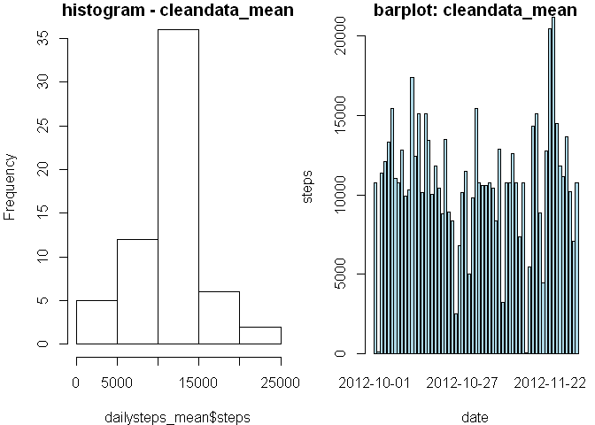

```r
par(mfrow = c(1, 2))
par(mar=c(4,4,1,0.5))

plot_004a <- hist(dailysteps_mean$steps, main = "histogram - cleandata_mean") # Histogram of steps per day (clean data)

plot_004b <- barplot(dailysteps_mean$steps, names.arg = dailysteps_mean$date, xlab = "date", ylab = "steps", col="light blue", main = "barplot: cleandata_mean")
```

```r
dev.copy(png,'plot_004.png')
```

png 3

```r
dev.off()
```

png 2

3.4b Calculate and report the mean and median total number of steps taken per day. ### Rcode 3.4b

```r
#Ans: This was 10766.19  from data with NA  (ie from daysteps$steps)
mean(dailysteps_mean$steps)
```

[1] 10766.19

```r
#10766.19 mean replace NAs (no difference)
mean(dailysteps_median$steps)
```

[1] 9354.23

```r
#9354.23 median replace NAs

#Ans: This was 10765 from data with NA (ie from daysteps$steps)
median(dailysteps_mean$steps)
```

[1] 10766.19

```r
#10766.19 mean replace NAs (minimal difference)
median(dailysteps_median$steps)
```

[1] 10395

```r
#10395 median replace NAs
```

3.4c Do these values differ from the estimates from the first part of the assignment? ##Answer 3.4c When the impute is Mean is no / minimal difference When the impute is Median there is significant difference Hence, for this dataset, the choice of mean is a better option for impute.

3.4d What is the impact of imputing missing data on the estimates of the total daily number of steps? ##Answer 3.4d Comparing daysteps (data with NAs) vs dailysteps (cleaned dataset), we do not see much diffrence. The impact in minimal for our stratergy of imputing missing data. ——————-

## Question 4.0

### Are there differences in activity patterns between weekdays and weekends?

4.1 Create a new factor variable in the dataset with two levels – “weekday” and “weekend” indicating whether a given date is a weekday or weekend day.

Create funtion to know daytype (weekday/weekend) ### Rcode 4.1a

```r
daytype <- function(date) {
    whichday <- weekdays(date)
    if (whichday %in% c("Monday", "Tuesday", "Wednesday", "Thursday", "Friday"))
        return("weekday")
    else (whichday %in% c("Saturday", "Sunday"))
        return("weekend")
}
```

Apply function_daytype on Data ### Rcode 4.1b

```r
Data$date <- as.Date(Data$date)
Data$daytype <- sapply(Data$date, FUN=daytype)

head(Data); table(Data$daytype)
```

steps date interval daytype 1 NA 2012-10-01 0 weekday 2 NA 2012-10-01 5 weekday 3 NA 2012-10-01 10 weekday 4 NA 2012-10-01 15 weekday 5 NA 2012-10-01 20 weekday 6 NA 2012-10-01 25 weekday

weekday weekend 12960 4608

4.2 Make a panel plot containing a time series plot (i.e. type = “l”) of the 5-minute interval (x-axis) and the average number of steps taken, averaged across all weekday days or weekend days (y-axis).

### Rcode 4.2

```r
weekdayAvg <- aggregate(steps ~ interval, data = Data, subset = Data$daytype == "weekday", FUN = mean)
weekendAvg <- aggregate(steps ~ interval, data = Data, subset = Data$daytype == "weekend", FUN = mean)
```

Plotting the comparison

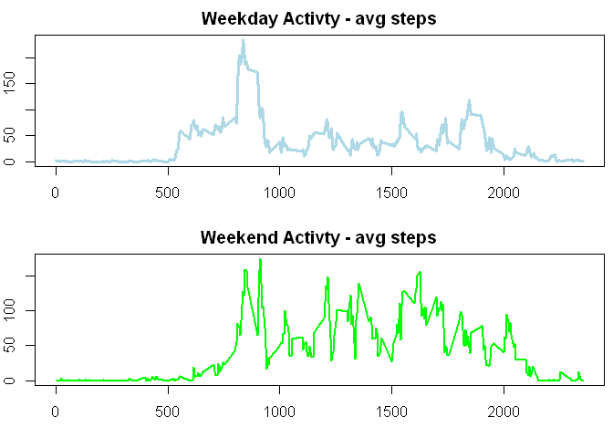

```r
par(mfrow = c(2, 1))
par(mar=c(3,2,2,0.5))

plot_005a <- plot(weekdayAvg , type = "l", main = "Weekday Activty - avg steps", col = "lightblue", lwd=3)

plot_005b <- plot(weekendAvg, type = "l", main = "Weekend Activty - avg steps", col = "green", lwd=2)
```

```r
dev.copy(png,'plot005.png')
```

png 3

```r
dev.off()
```

png 2

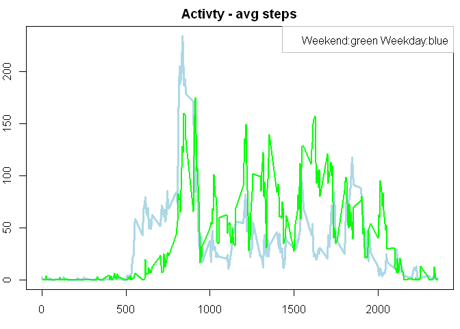

```r
par(mfrow = c(1, 1))
par(mar=c(3,2,2,0.5))

plot_006 <- plot(weekdayAvg , type = "l", col = "lightblue", lwd =3, xlab="interval", ylab="avg steps", main ="Activty - avg steps")
lines(weekendAvg, type = "l", col = "green", lwd=2)
legend("topright", legend = "Weekend:green Weekday:blue", box.col=8)
```

```r
dev.copy(png,'plot006.png')
```

png 3

```r
dev.off()
```

png 2

## Answer 4.0

Yes, there is a difference in patters of activity between weekdays and weekends?

Weekday activity sees sudden rise start at interval 500. There is lot more activity on weekends for interval 1000-2000